# STAT 627 Final Project: Enhanced Regression Modeling

Thaina Gomez

```r
data <- read_csv("diabetes_prediction_dataset.csv")
```

```r
# Convert appropriate variables to factors
data <- data %>%
  mutate(across(c(gender, hypertension, heart_disease, smoking_history), as.factor))
```

## Histogram of HbA1c

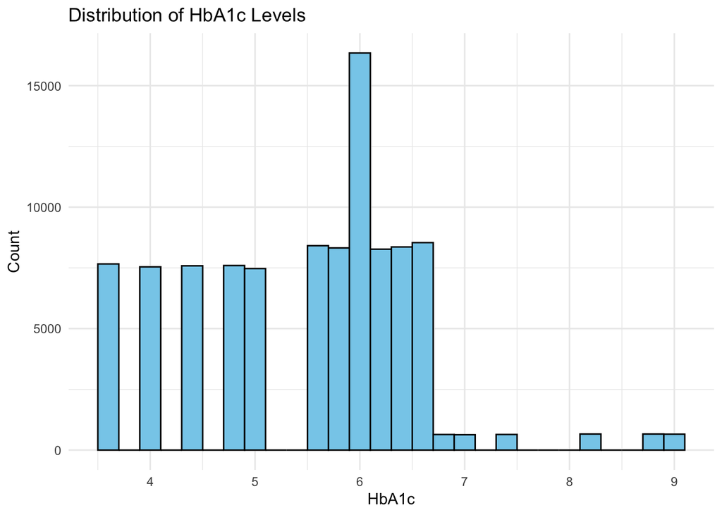

```r
ggplot(data, aes(HbA1c_level)) +
  geom_histogram(binwidth = 0.2, fill = "skyblue", color = "black") +
  labs(title = "Distribution of HbA1c Levels", x = "HbA1c", y = "Count") +
  theme_minimal()
```

## Correlation Matrix

```r
numeric_vars <- dplyr::select(data, age, bmi, blood_glucose_level, HbA1c_level)
corr_matrix <- cor(numeric_vars, use = "complete.obs")
print(corr_matrix)
```

```
##                           age        bmi blood_glucose_level HbA1c_level
## age                 1.0000000 0.33739578           0.1106723  0.10135366
## bmi                 0.3373958 1.00000000           0.0912614  0.08299716
## blood_glucose_level 0.1106723 0.09126140           1.0000000  0.16673293
## HbA1c_level         0.1013537 0.08299716           0.1667329  1.00000000
```

##Age × BMI interaction #Trends in HbA1c levels relative to BMI differ among various age groups, with stronger positive associations found in older adults. This observation supports the inclusion of an age × BMI interaction term in the regression model. Incorporating this interaction term allows the model to account for the potential modification effect of age. Boye et al. (2021) demonstrated that the relationship between BMI and HbA1c varied by age group, with the strongest association occurring in adults aged 18 to 44, further confirming age as an effect modifier. # Source: Boye KS, Lage MJ, Shinde S, Thieu V, Bae JP. (2021). Trends in HbA1c and Body Mass Index Among Individuals with Type 2 Diabetes. # Diabetes Ther. 12(7), 2077–2087. doi:10.1007/s13300-021-01084-0

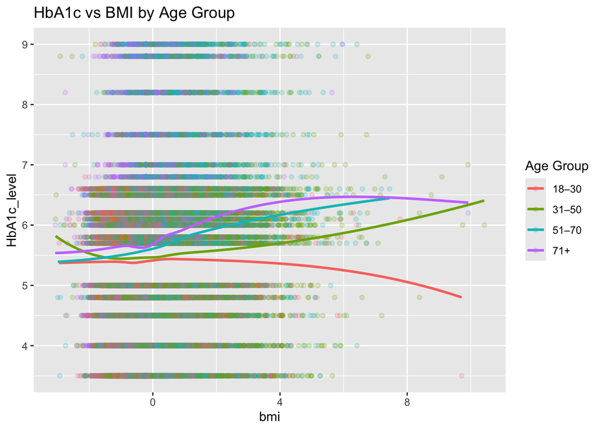

```r
data <- data %>% filter(age >= 18)

# Create age groups before scaling
data <- data %>%
  mutate(age_group = cut(age,
                         breaks = c(18, 30, 50, 70, Inf),
                         labels = c("18–30", "31–50", "51–70", "71+")))

# Now scale (if needed)
train_scaled <- data %>%
  mutate(across(c(age, bmi, blood_glucose_level), scale)) %>%
  filter(!is.na(age_group))

# Plot
ggplot(train_scaled, aes(x = bmi, y = HbA1c_level, color = age_group)) +
  geom_point(alpha = 0.2) +
  geom_smooth(method = "loess", se = FALSE) +
  labs(title = "HbA1c vs BMI by Age Group", color = "Age Group")
```

##Polynomial term for blood_glucose_level #The relationship between blood glucose and HbA1c is known to be non-linear, particularly in the pre-diabetic and diabetic ranges Rohlfing et al. (2002). Including a second-degree polynomial term allows the model to better capture this curvilinear pattern and improve predictive accuracy. # Source: Rohlfing, C. L., Wiedmeyer, H.-M., Little, R. R., England, J. D., Tennill, A., & Goldstein, D. E. (2002). Defining the relationship between plasma glucose and HbA1c: Analysis of glucose profiles and HbA1c in the Diabetes Control and Complications Trial. Diabetes Care, 25(2), 275–278. https://doi.org/10.2337/diacare.25.2.275

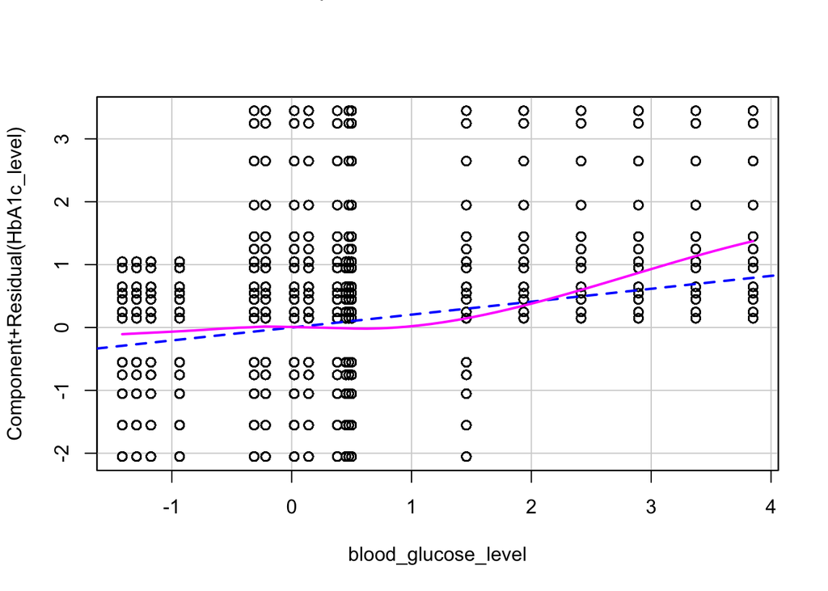

```r
crPlots(lm(HbA1c_level ~ blood_glucose_level, data = train_scaled))
```

```r
set.seed(123)
train_index <- createDataPartition(data$HbA1c_level, p = 0.8, list = FALSE)
train_data <- data[train_index, ]
test_data  <- data[-train_index, ]
preProc <- preProcess(train_data, method = c("center", "scale"))
train_scaled <- predict(preProc, train_data)
test_scaled <- predict(preProc, test_data)
train_control <- trainControl(method = "cv", number = 10)
```

## Linear Regression with Interactions

#This model includes an interaction term between age and BMI, as well as a second-degree polynomial term for blood glucose level. We included interaction terms because a scatterplot of HbA1c against BMI, colored by age, showed different slopes for different age groups. This indicates that BMI’s effect on HbA1c may vary with age. Furthermore, a component and residual plot showed that the relationship with blood glucose level is non-linear, which supports using a polynomial term. Both the interaction and polynomial terms were statistically significant (p < 0.001), and the variance inflation factors (VIFs) were below 2, confirming there is no serious multicollinearity.

```r
set.seed(123)
lm_cv <- train(
  HbA1c_level ~ age * bmi + poly(blood_glucose_level, 2) + gender + hypertension + heart_disease + smoking_history,
  data = train_scaled,
  method = "lm",
  trControl = train_control
)
lm_cv$results
```

```
##   intercept      RMSE   Rsquared       MAE      RMSESD  RsquaredSD       MAESD
## 1      TRUE 0.9683497 0.06231163 0.8058527 0.007428668 0.003957909 0.004344512
```

```r
lm_model <- lm(HbA1c_level ~ age * bmi + poly(blood_glucose_level, 2) + gender + hypertension + heart_disease + smoking_history,
               data = train_scaled)
summary(lm_model)
```

```
##
## Call:
## lm(formula = HbA1c_level ~ age * bmi + poly(blood_glucose_level,
##     2) + gender + hypertension + heart_disease + smoking_history,
##     data = train_scaled)
##
## Residuals:
##     Min      1Q  Median      3Q     Max
## -2.5627 -0.7214  0.2671  0.6655  3.3861
##
## Coefficients:
##                                Estimate Std. Error t value Pr(>|t|)
## (Intercept)                   -0.022995   0.011979  -1.920   0.0549 .
## age                            0.062817   0.004104  15.308  < 2e-16 ***
## bmi                            0.048217   0.003840  12.557  < 2e-16 ***
## poly(blood_glucose_level, 2)1 43.037203   0.982134  43.820  < 2e-16 ***
## poly(blood_glucose_level, 2)2 29.453602   0.974383  30.228  < 2e-16 ***
## genderMale                     0.033642   0.007782   4.323 1.54e-05 ***
## genderOther                    0.284182   0.279624   1.016   0.3095
## hypertension1                  0.126132   0.013616   9.264  < 2e-16 ***
## heart_disease1                 0.139723   0.018193   7.680 1.61e-14 ***
## smoking_historyever            0.001113   0.020556   0.054   0.9568
## smoking_historyformer          0.004019   0.016175   0.248   0.8037
## smoking_historynever          -0.000217   0.012888  -0.017   0.9866
## smoking_historyNo Info        -0.041791   0.013454  -3.106   0.0019 **
## smoking_historynot current     0.008183   0.018049   0.453   0.6503
## age:bmi                        0.037301   0.004172   8.940  < 2e-16 ***
## ---
## Signif. codes:  0 '***' 0.001 '**' 0.01 '*' 0.05 '.' 0.1 ' ' 1
##
## Residual standard error: 0.9683 on 66212 degrees of freedom
## Multiple R-squared:  0.06266,    Adjusted R-squared:  0.06246
## F-statistic: 316.1 on 14 and 66212 DF,  p-value: < 2.2e-16
```

```r
vif(lm_model)
```

```
## there are higher-order terms (interactions) in this model
## consider setting type = 'predictor'; see ?vif
```

```
##                                  GVIF Df GVIF^(1/(2*Df))
## age                          1.189460  1        1.090624
## bmi                          1.041422  1        1.020501
## poly(blood_glucose_level, 2) 1.041526  2        1.010224
## gender                       1.023086  2        1.005722
## hypertension                 1.079566  1        1.039022
## heart_disease                1.078959  1        1.038729
## smoking_history              1.068340  5        1.006633
## age:bmi                      1.053322  1        1.026315
```

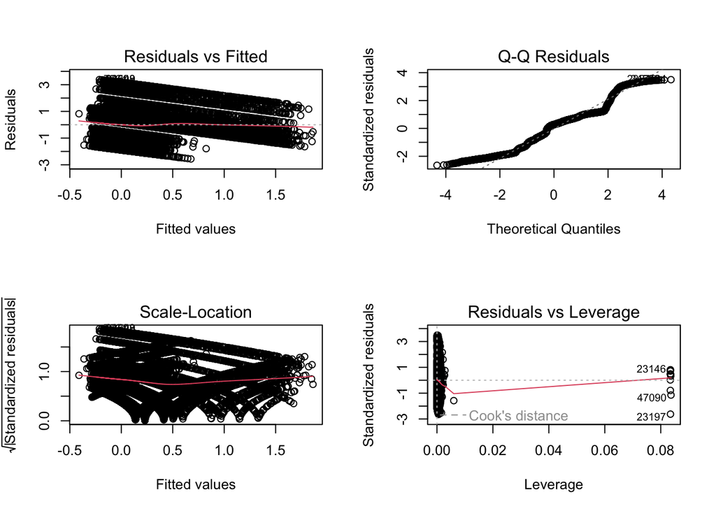

```r
par(mfrow = c(2, 2))
plot(lm_model)
```

## Regression Tree

#The diagnostic plots from the linear model showed that the residuals had some curvature and revealed possible interactions that were not manually included. We used Regression Trees to automatically find non-linear splits and higher-order interactions. This approach made the results easier to understand and helped us pinpoint important decision thresholds, like glucose cutoffs.

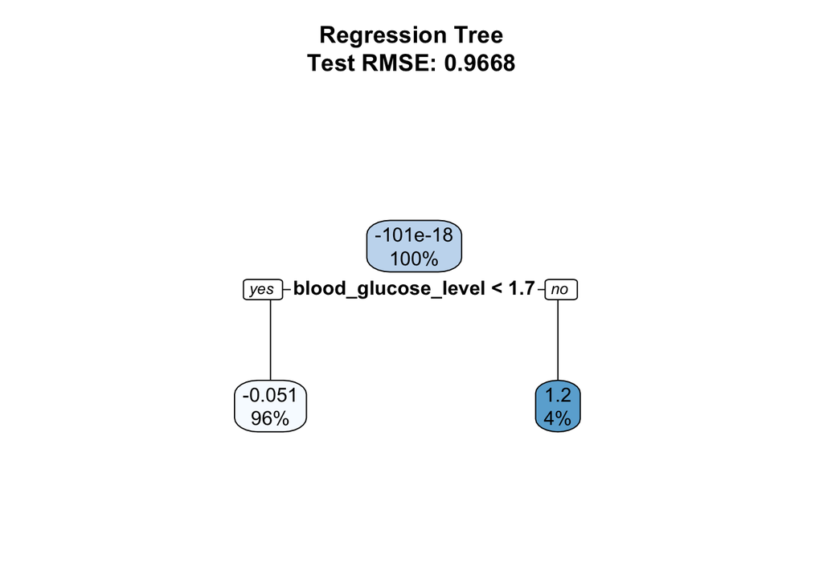

```r
# Fit and plot the tree
tree_model <- rpart(HbA1c_level ~ age + bmi + blood_glucose_level + gender + hypertension + heart_disease + smoking_history,
                    data = train_scaled, method = "anova")

tree_pred <- predict(tree_model, test_scaled)
tree_rmse <- sqrt(mean((tree_pred - test_scaled$HbA1c_level)^2))

rpart.plot(tree_model, main = paste("Regression Tree\nTest RMSE:", round(tree_rmse, 4)))
```

## Lasso and Ridge Regression

#We used these models for regularization and feature selection. We chose Lasso because it can reduce irrelevant coefficients to zero, which is helpful for predictors like smoking_history that have many categories. We included Ridge to compare how both models handle shrinkage when we assume all variables are important. We tuned both models using cross-validation to find the best lambda for improving accuracy and preventing overfitting.

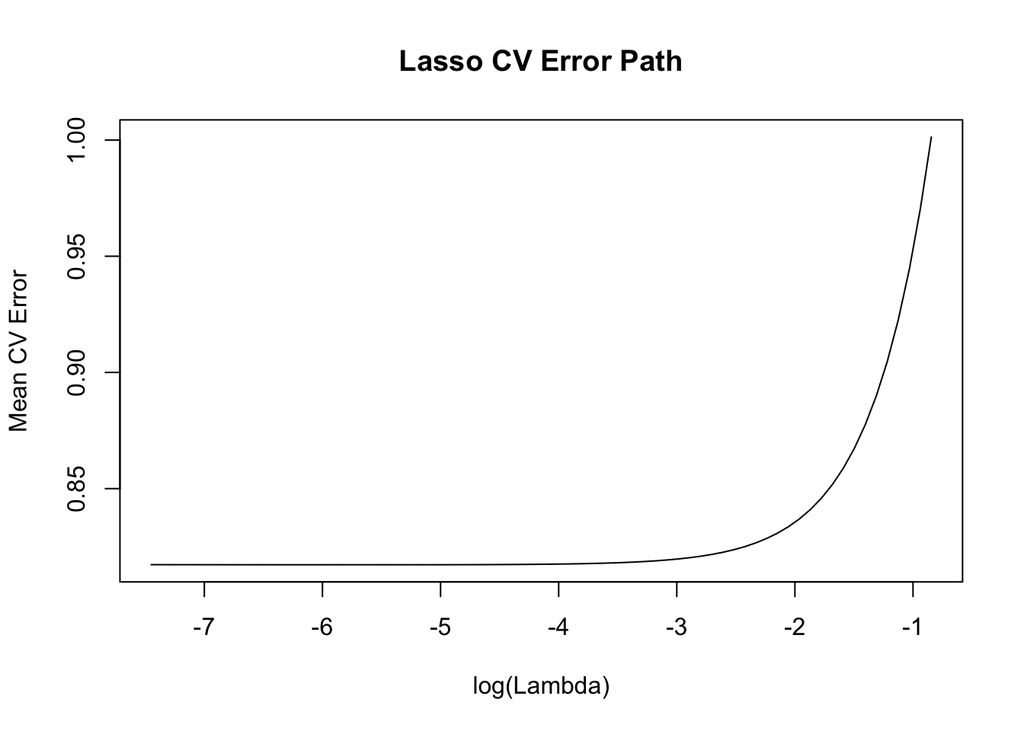

```r
train_scaled <- train_scaled %>% drop_na()
test_scaled  <- test_scaled %>% drop_na()
x_train <- model.matrix(HbA1c_level ~ ., train_scaled)[, -1]
y_train <- train_scaled$HbA1c_level
x_test <- model.matrix(HbA1c_level ~ ., test_scaled)[, -1]
y_test <- test_scaled$HbA1c_level

# Lasso
lasso_model <- cv.glmnet(x_train, y_train, alpha = 1, keep = TRUE)
plot(log(lasso_model$lambda), lasso_model$cvm, type = "l",
     xlab = "log(Lambda)", ylab = "Mean CV Error", main = "Lasso CV Error Path")
```

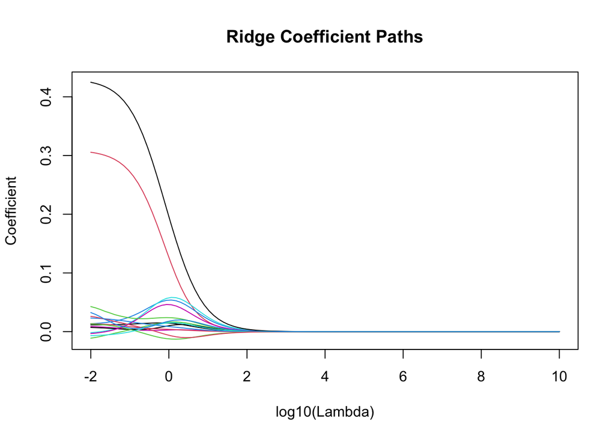

```r
lasso_pred <- predict(lasso_model, s = "lambda.min", newx = x_test)
lasso_rmse <- sqrt(mean((lasso_pred - y_test)^2))

# Ridge
ridge_model <- cv.glmnet(x_train, y_train, alpha = 0)
ridge_pred <- predict(ridge_model, s = "lambda.min", newx = x_test)
ridge_rmse <- sqrt(mean((ridge_pred - y_test)^2))

# Ridge Coefficient Paths
alphas <- 10^seq(10, -2, length = 100)
ridge_coefs <- sapply(alphas, function(a) {
  fit <- glmnet(x_train, y_train, alpha = 0, lambda = a)
  as.vector(coef(fit))[-1]
})
matplot(log10(alphas), t(ridge_coefs), type = "l", lty = 1,
        xlab = "log10(Lambda)", ylab = "Coefficient", main = "Ridge Coefficient Paths")
```

## Compare All Models

#Linear Regression showed a strong baseline with easy-to-understand coefficients, but its higher RMSE suggests it struggles with non-linear patterns and interactions beyond the age × BMI term. Lasso & Ridge Regression models had the lowest RMSE (about 0.905), making them the best options. Lasso is particularly helpful for selecting important features. Both are recommended depending on the analysis goal.

```r
lm_pred <- predict(lm_model, test_scaled)
lm_rmse <- sqrt(mean((lm_pred - test_scaled$HbA1c_level)^2))

rmse_results <- tibble(
  Model = c("Linear (w/ interactions)", "Tree", "Lasso", "Ridge"),
  RMSE = c(lm_rmse, tree_rmse, lasso_rmse, ridge_rmse)
)

print(rmse_results)
```

```
## # A tibble: 4 × 2
##   Model                     RMSE
##   <chr>                    <dbl>
## 1 Linear (w/ interactions) 0.968
## 2 Tree                     0.967
## 3 Lasso                    0.905
## 4 Ridge                    0.905
```